1. Wczytaj dane, obejrzyj je i podsumuj w dwóch-trzech zdaniach.

```r
people <- read.csv("people.tab", header=TRUE, sep="\t")
attach(people)
View(people)
```

pozostałe zmienne są zmiennymi objaśniającymi (niezależnymi): `age, weight, height, gender, married, number_of_kids, pet`

### Zadanie1.

Ile jest obserwacji, ile zmiennych ilościowych, a ile jakościowych? #### Zmienne jakościowe: married, gender, pet #### Zmienne ilościowe: * age, weight, height, number_of_kids, expenses ### Obserwacji: 500.

```r
length(people$age) # obserwacja ilość
```

```
## [1] 500
```

### Zmienne objaśniająće:

Czy są zależności w zmiennych objaśniających (policz i podaj VIF)?

VIF - czynnik infalcji wariancji

```r
#install.packages("car")

library(car)
model_rl <- lm(expenses ~ ., data=people)
vif(model_rl)
```

```
##                    GVIF Df GVIF^(1/(2*Df))
## age            1.008430  1        1.004206
## weight         1.822536  1        1.350013
## height         1.824757  1        1.350836
## gender         1.029538  2        1.007304
## married        1.664691  1        1.290229
## number_of_kids 1.649830  1        1.284457
## pet            1.045822  4        1.005616
```

VIF dla każdego z predyktorów jest w okolicach 1 lub 2, wówczas nie mamy przesłanek by twierdzić dużej współliniowości predyktór.

Czy występują jakieś braki danych?

```r
which(is.na(people))
```

```
## integer(0)
```

To oznacza, że nie mamy braków w danych.

UWAGA: zmienną `expenses` z ujemnymi wagami interpretuje jako przychód

2. Podsumuj dane przynajmniej trzema różnymi wykresami. Należy przygotować:

Wykres pokazująćy jak zmienne objaśniające zależa od siebie, oraz jak zmienna objaśniana `expenses` zależy od wszystkich

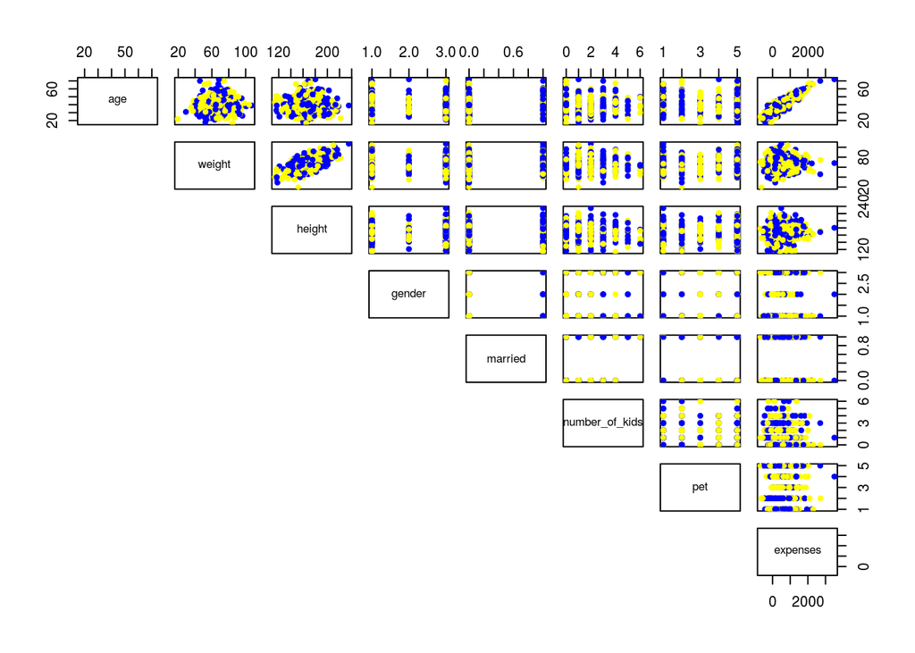

```r
my_cols <- c("blue", "yellow")
pairs(people[, c(1,2,3,4,5,6,7,8)], pch = 19,  cex = 0.7, col = my_cols[], lower.panel = NULL)
```

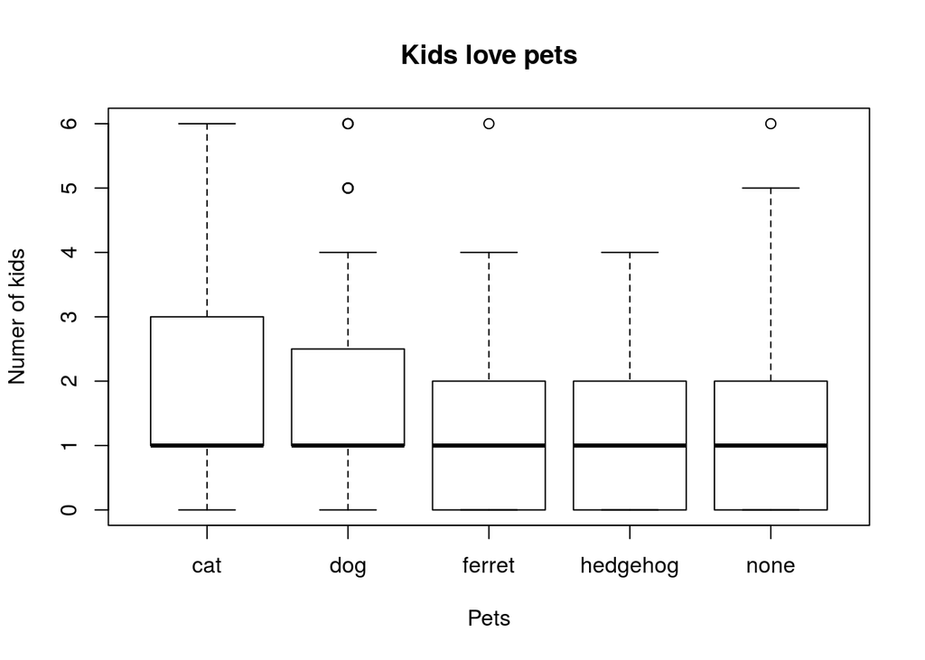

```r
 boxplot(number_of_kids~pet, data=people, main="Kids love pets",
   xlab="Pets", ylab="Numer of kids")
```

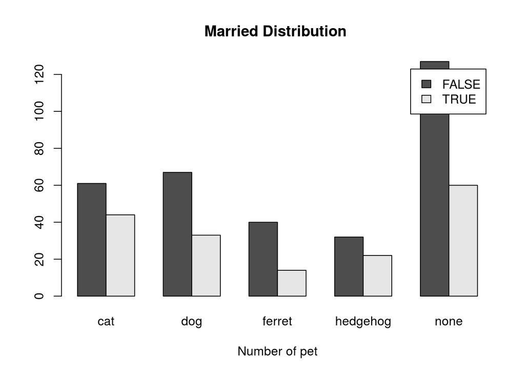

```r
counts <- table(people$married, people$pet)
barplot(counts, main="Married Distribution ",
   xlab="Number of pet", legend = rownames(counts),  beside=TRUE)
```

Dodatkowo:

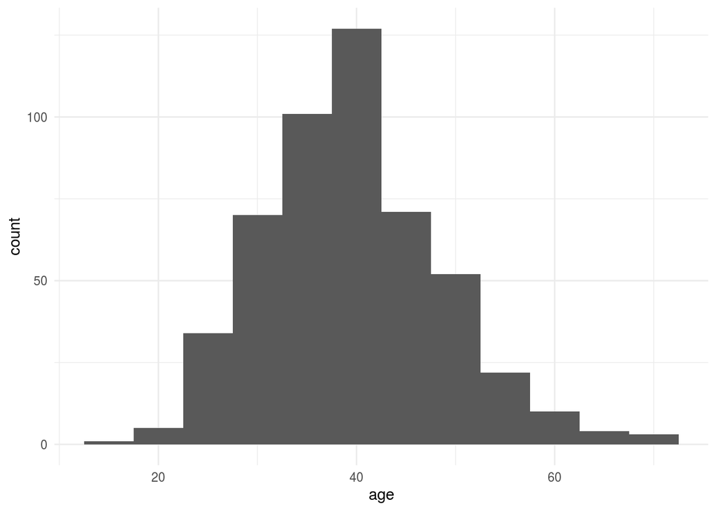

```r
library(ggplot2)
ggplot(people) + geom_histogram(aes(x=age), binwidth=5) + theme_minimal()
```

### Zadanie2

#### Róznica między średnią wartością wybranej zmiennej:

Wykorzystuje test t-Studenta dla populacji o różnych licznościach, ale równych wariancjach (Wykład 2). Zakładamy poziom istotności $\alpha = 0.05$

```r
shapiro.test(people$weight)
```

```
##
##  Shapiro-Wilk normality test
##
## data:  people$weight
## W = 0.99895, p-value = 0.9939
```

p-wartość > 0.05 daję nam, że dane pochodzą z rozkładu normalnego.

```r
x = people$weight[people$gender == "man"] # filtruje dane
y = people$weight[people$gender == "woman"] #

t.test(x, y, var.equal = TRUE) # wykonuje test
```

```
##
##  Two Sample t-test
##
## data:  x and y
## t = 1.4361, df = 460, p-value = 0.1517
## alternative hypothesis: true difference in means is not equal to 0
## 95 percent confidence interval:
##  -0.6363096  4.0909130
## sample estimates:
## mean of x mean of y
##  67.35157  65.62427
```

#### Niezależności między dwoma zmiennymi ilościowymi:

Dana jest próba losowa postaci $(X_1, Y_1), \ldots (X_n,Y_n)$, gdzie X to `expenses` a Y to `age`

```r
  X = people$expenses
  Y = people$age
```

Formuje hipotezę:
$$H_0: \text{X i Y są niezależne}$$
przeciw:
$$H_1: \text{istnieje jakikolwiek rodzaj zależności między X i Y}$$

Wyliczamy statystykę testu Pearsona.

```r
cor(X,Y,method="pearson")
```

```
## [1] 0.8927856
```

```r
cor.test(X, Y,method="pearson")
```

```
##
##  Pearson's product-moment correlation
##
## data:  X and Y
## t = 44.227, df = 498, p-value < 2.2e-16
## alternative hypothesis: true correlation is not equal to 0
## 95 percent confidence interval:
##  0.8734787 0.9092890
## sample estimates:
##       cor
## 0.8927856
```

Nasz współcznnik jest na poziomie 0.8., wówczas przyjmujemy hipotezę alternatywną, że nasze dane są zależne.

#### Jedną dot. niezależności między dwoma zmiennymi jakościowymi

W tym celu wykorzystam Chi-square pearsona.
$$H_0: \text{zmienne X i Y są niezależne}$$
przeciwko:
$$H_1: \text{zmienne X i Y są zależne}$$
Wynkonuje test na poziomie istotności $\alpha = 0.05$

Buduję macierz kontygnencji:

```r
  confusion_matrix<- table(people$gender, people$married)
```

```r
head(confusion_matrix)
```

```
##
##         FALSE TRUE
##   man     154   69
##   other    25   13
##   woman   148   91
```

```r
chisq <- chisq.test(confusion_matrix)
```

```r
chisq
```

```
##
##  Pearson's Chi-squared test
##
## data:  confusion_matrix
## X-squared = 2.5971, df = 2, p-value = 0.2729
```

$p-value > \alpha$, więc nie ma zależności pomiędzy grupami.

#### Jedna dot. rozkładu zmiennej (np. “zmienna A ma rozkład wykładniczy z parametrem 10”)

```r
  ks.test(height, "pexp", 3)
```

```
##
##  One-sample Kolmogorov-Smirnov test
##
## data:  height
## D = 1, p-value < 2.2e-16
## alternative hypothesis: two-sided
```

### Zadanie3

3.Podaj przedziały ufności dla wartości średniej i wariancji dla zmiennych wiek i wzrost. Jeżeli w celu wyliczenia przedziału ufności musisz poczynić jakieś założenia(np.założyć że zmienna pochodzi z rozkładu normalnego), zaznacz to i skomentuj czy wydaje Ci się to w danym przypadku uprawnione. Opisz wszelkie dodatkowe operacje, jakie zostały wykonane przed testem(takie jak usunięcie obserwacji odstających). Przedyskutuj, dla której ze zmiennych oczekujesz prawidłowych wyników.

W celu sprawdzenia normalności danych wykonuje test Test Shapiro-Wilka:
$$H_0 : \text{Wzrost pochodzi z populacji o rozkładzie normalnym}$$
przeciw alternatywnej:
$$H_1: \text{Wzrost nie pochodzi z populacji o rozkładzie normalnym}$$

```r
shapiro.test(people$height)
```

```
##
##  Shapiro-Wilk normality test
##
## data:  people$height
## W = 0.99662, p-value = 0.3778
```

$\texttt{p-wartość} > 0.05$ wówczas rozkład naszych danych nie znacząco różni się od rozkładu normalego. Więc dane pochodzą właśnie z takiego rozkładu.

I analogicznie dla zmiennej `age`

```r
shapiro.test(people$age)
```

```
##
##  Shapiro-Wilk normality test
##
## data:  people$age
## W = 0.98179, p-value = 6.589e-06
```

Widzmy, że zmienna dla zmiennej `age` $p < \alpha$ wówczas odrzucamy hipotezę zerowa.

Pokazuje to również wykres kwantylowy

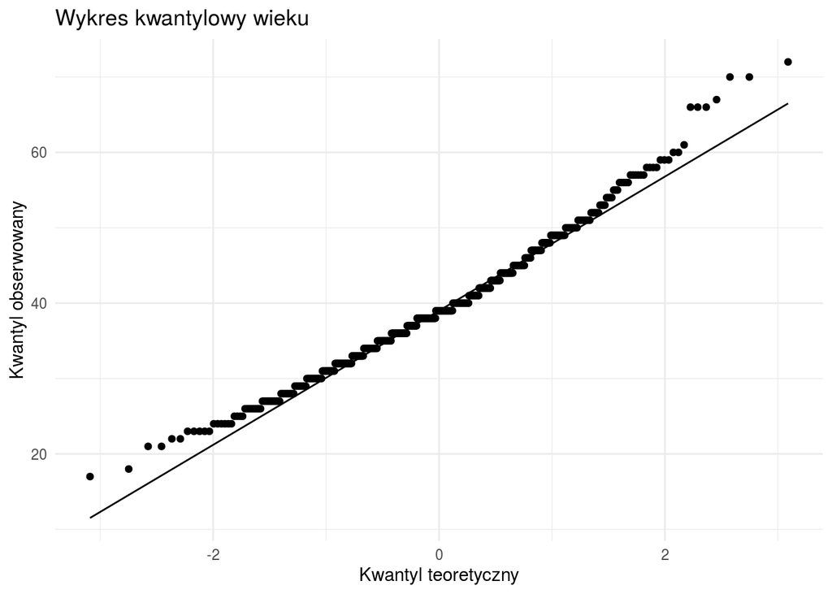

```r
library(ggplot2)

qqplot_age <- ggplot(people) + stat_qq(aes(sample=age)) + stat_qq_line(aes(sample=age)) + theme_minimal() + ggtitle('Wykres kwantylowy wieku') + xlab('Kwantyl teoretyczny') + ylab('Kwantyl obserwowany')
# Usuwam tylko nie wygodne dane,
qqplot_age
```

Postanowiłem usnąc tylko obserwacje, które nie są naturalne dla zmiennej `height`. *Stosując metodę 1.5 IQR, usunąłbym za dużo znaczących zmiennych.*

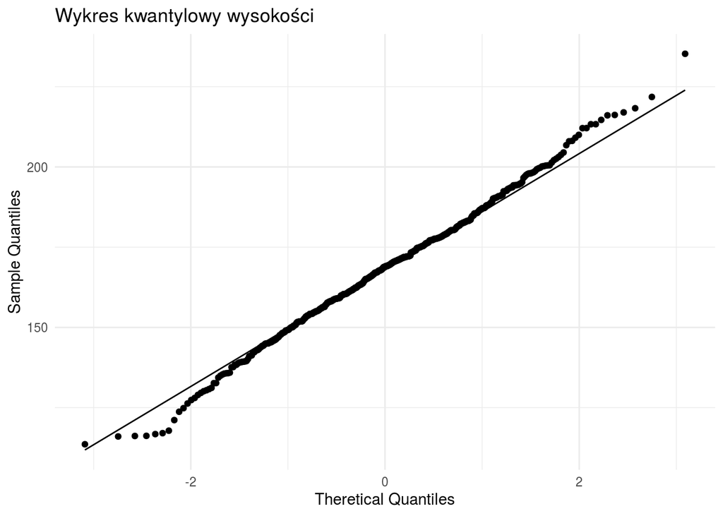

```r
library(ggplot2)
qqplot_height <- ggplot(people) + stat_qq(aes(sample=height)) + stat_qq_line(aes(sample=height)) + theme_minimal() + ggtitle('Wykres kwantylowy wysokości') + xlab('Theretical Quantiles') + ylab('Sample Quantiles')
qqplot_height
```

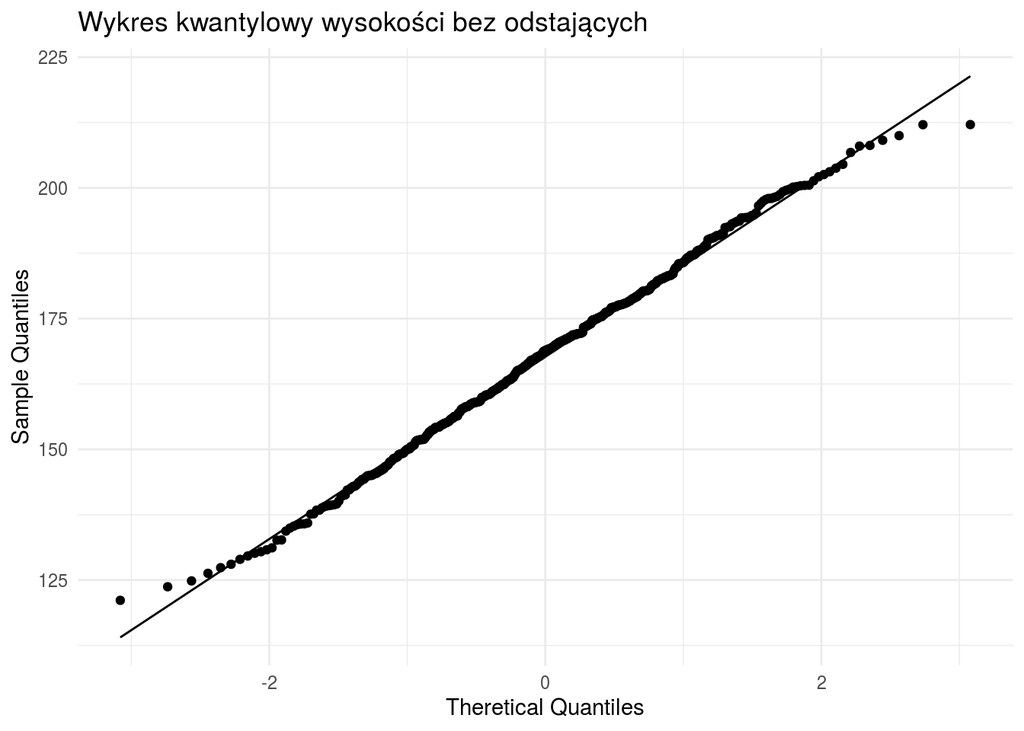

```r
# Usuwam wysokości odstające mocno(mogą sugerować błędne dane)
people <- people[-c(241, 356, 419, 458, 194, 51, 64, 161, 364, 413, 256, 207, 39, 199, 215, 362, 247, 467), ]

qqplot_age <- ggplot(people) + stat_qq(aes(sample=height)) + stat_qq_line(aes(sample=height)) + theme_minimal() + ggtitle('Wykres kwantylowy wysokości bez odstających') + xlab('Theretical Quantiles') + ylab('Sample Quantiles')
qqplot_age
```

```r
summary(people$height)
```

```
##    Min. 1st Qu.  Median    Mean 3rd Qu.    Max.
##   121.1   155.9   168.9   168.0   179.4   212.1
```

Widzimy z wykresów kwantowlowych wysokości, że założenie o rozkładu próbki jako rozkładu normalności jest spełnione.

Przy założeniu, że zmienna `height` ma rozkład normalny, ustalam próg ufności $\alpha = 0.05$. ### Przedział ufności dla średniej

```r
alpha <- 0.05
X = people$height
n <- nrow(people)
q <- qt(1-alpha/2, n-1)
height_mean = mean(X)
height_sd = sd(X)
student.interval <- c(height_mean - q*height_sd/sqrt(n-1), height_mean + q*height_sd/sqrt(n-1))
print(student.interval)
```

```
## [1] 166.4197 169.5916
```

```r
height_mean
```

```
## [1] 168.0056
```

```r
height_sd
```

```
## [1] 17.70208
```

Dla 95 na 100 powtórzeń obliczony przedział będzie zawierał prawdziwą nieznaną wartość średnią dla zmiennej `height`

na poziomie istotności $\alpha = 0.05$

```r
sqrt(height_sd*length(X)/qchisq(c(1-.025,.025), length(X)-1))
```

```
## [1] 3.961605 4.495882
```

### Zadanie5

Oszacuj model regresji linowej, przyjmując za zmienną zależną (y) wydatki domowe (expenses) a zmienne niezależne (x) wybierając spośród pozostałych zmiennych. Rozważ, czy konieczne są transformacje zmiennych lub zmiennej objaśnianej.

Podaj RSS, $R^2$ , p-wartości i oszacowania współczynników i wybierz właściwe zmienne objaśniające, które najlepiej tłumaczą `expenses`. Sprawdź czy w wybranym przez Ciebie modelu spełnione są założenia modelu liniowego i przedstaw na wykresach diagnostycznych: wykresie zależności reszt od zmiennej objaśnianej,na wykresie reszt studentyzowanych i na wykresie dźwigni i przedyskutuj, czy są spełnione.

Mój pierwszy krok, to zbudowanie modelu z wszystkimi predyktorami, a więc: `expenses ~ .`

Następnie chce wybrać tylko istotne predyktory.

Z wykładu wykorzystuje podstawowe techniki wyszukiwania

```r
library(MASS)
# Fit the full model
full.model <- lm(expenses ~., data = people)
summ_full <- summary(full.model)
summ_full
```

```
##
## Call:
## lm(formula = expenses ~ ., data = people)
##
## Residuals:
##     Min      1Q  Median      3Q     Max
## -766.59 -130.32   -1.03  129.59  913.84
##
## Coefficients:
##                  Estimate Std. Error t value Pr(>|t|)
## (Intercept)    -2260.2366   110.0728 -20.534  < 2e-16 ***
## age               57.5813     1.0862  53.012  < 2e-16 ***
## weight             1.2415     1.0146   1.224  0.22172
## height             1.9504     0.7202   2.708  0.00701 **
## genderother       44.3687    38.4196   1.155  0.24874
## genderwoman      -20.7635    20.6079  -1.008  0.31419
## marriedTRUE       -9.2049    26.6730  -0.345  0.73017
## number_of_kids   -12.9377     9.0626  -1.428  0.15407
## petdog            26.3487    30.6030   0.861  0.38969
## petferret        407.8099    36.7762  11.089  < 2e-16 ***
## pethedgehog      236.6419    37.1349   6.372 4.44e-10 ***
## petnone           21.2643    26.6442   0.798  0.42522
## ---
## Signif. codes:  0 '***' 0.001 '**' 0.01 '*' 0.05 '.' 0.1 ' ' 1
##
## Residual standard error: 214.5 on 470 degrees of freedom
## Multiple R-squared:  0.8624, Adjusted R-squared:  0.8591
## F-statistic: 267.7 on 11 and 470 DF,  p-value: < 2.2e-16
```

```r
RSS <- sum(resid(full.model)^2)
RSS
```

```
## [1] 21624952
```

```r
r2 <- summ_full$r.squared
r2
```

```
## [1] 0.8623641
```

### Stepwise regression model- podejście z wykładu

```r
# Stepwise regression model
step.model <- stepAIC(full.model, direction = "both",
                      trace = FALSE, x = TRUE)
summary_step = summary(step.model)
```

#### Sprawdzenie, czy w moim modelu są spełnione założenia modelu linowego.

Resztowa suma kwadratów

```r
RSS <- sum(resid(step.model)^2)
RSS
```

```
## [1] 21857854
```

```r
r2 <- summary_step$r.squared
r2
```

```
## [1] 0.8608817
```

P-wartość: p-value: < 2.2e-16

#### Wykres wartości resztowych:

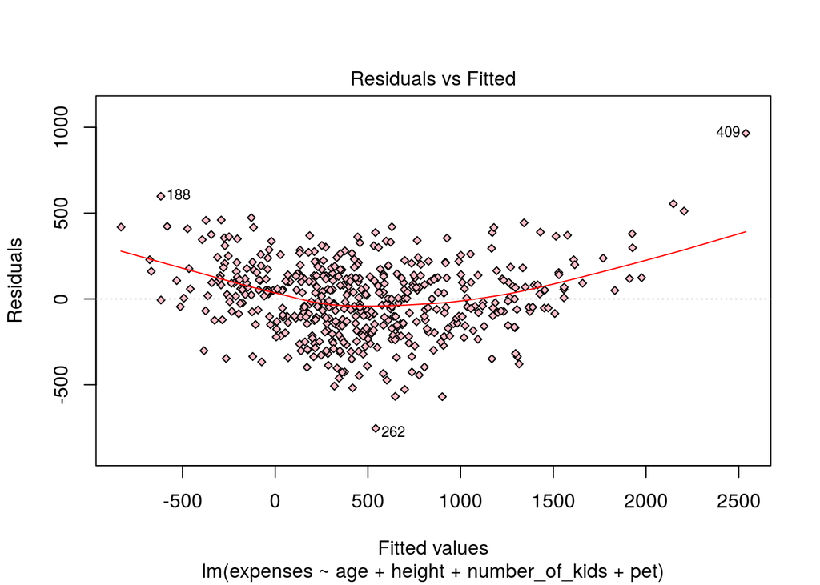

```r
par(mfrow=c(1,1))
plot(step.model, pch=23, bg='pink', cex=0.7, which= 1)
```

widzimy, że linowość jest naruszona Wydaje się, że jest to relacja kwadratowa. Nie zauważamy wykresy “lejka”, który sugeruję zmienność wariancji. Można przyjać założenie modelu, że każdy błąd ma tą samą wariancje.

Na wykresie widzimy również oberwacje odstające: `262`, `188`, `409`. Usunięcie takich danych zmieni miarę jakości dopasowania.

#### Wykres dźwigni:

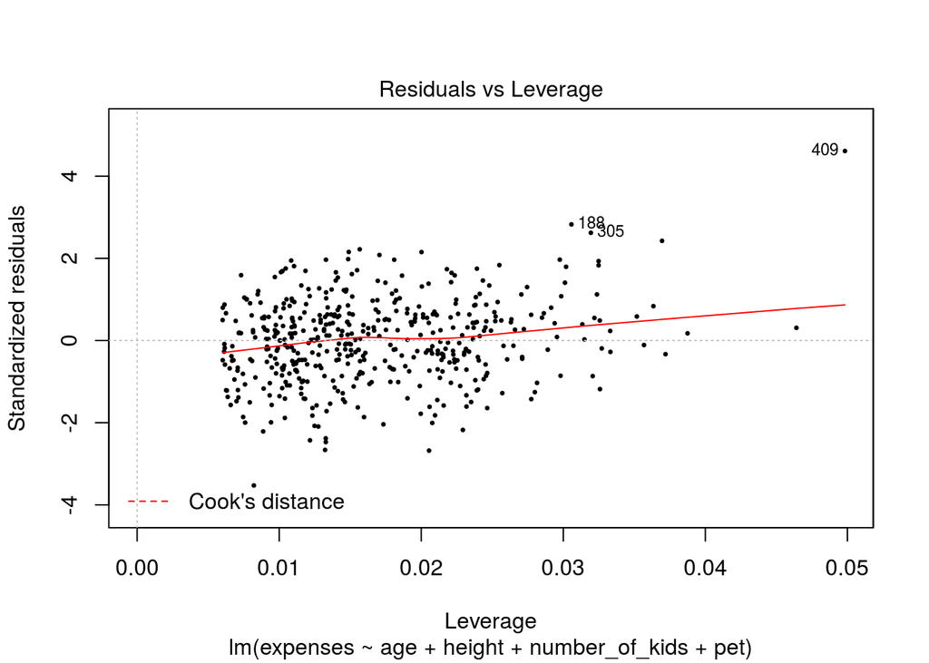

```r
par(mfrow=c(1,1))
plot(step.model, pch=20 ,bg='pink', cex=0.5, which=5)
```

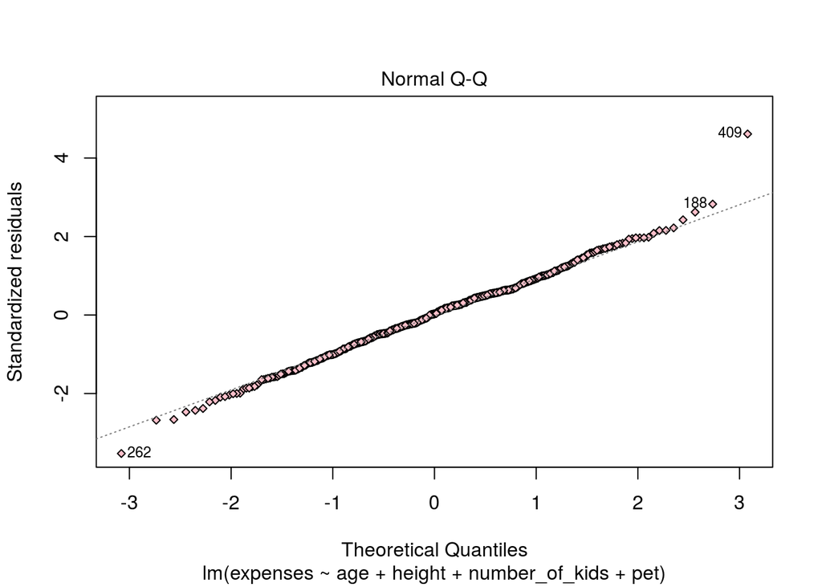

```r
plot(step.model, pch=23, bg='pink', cex=0.7, which= 2)
```

```r
eruption.res = resid(step.model)
```

### dodatkowa diagnostyka:

```r
library(gvlma)
gvmodel <- gvlma(step.model)
summary(gvmodel)
```

```
##
## Call:
## lm(formula = expenses ~ age + height + number_of_kids + pet,
##     data = people)
##
## Residuals:
##     Min      1Q  Median      3Q     Max
## -754.45 -139.95    6.11  131.32  965.54
##
## Coefficients:
##                  Estimate Std. Error t value Pr(>|t|)
## (Intercept)    -2275.1953   108.8158 -20.909  < 2e-16 ***
## age               57.4717     1.0856  52.941  < 2e-16 ***
## height             2.5105     0.5577   4.502 8.50e-06 ***
## number_of_kids   -14.6045     7.0733  -2.065   0.0395 *
## petdog            27.6295    30.4787   0.907   0.3651
## petferret        410.5730    36.6254  11.210  < 2e-16 ***
## pethedgehog      237.6588    37.1688   6.394 3.88e-10 ***
## petnone           20.7579    26.6102   0.780   0.4357
## ---
## Signif. codes:  0 '***' 0.001 '**' 0.01 '*' 0.05 '.' 0.1 ' ' 1
##
## Residual standard error: 214.7 on 474 degrees of freedom
## Multiple R-squared:  0.8609, Adjusted R-squared:  0.8588
## F-statistic:   419 on 7 and 474 DF,  p-value: < 2.2e-16
##
##
## ASSESSMENT OF THE LINEAR MODEL ASSUMPTIONS
## USING THE GLOBAL TEST ON 4 DEGREES-OF-FREEDOM:
## Level of Significance =  0.05
##
## Call:
##  gvlma(x = step.model)
##
##                      Value   p-value                   Decision
## Global Stat        93.5393 0.0000000 Assumptions NOT satisfied!
## Skewness            0.1509 0.6976979    Assumptions acceptable.
## Kurtosis           10.8843 0.0009698 Assumptions NOT satisfied!
## Link Function      82.1359 0.0000000 Assumptions NOT satisfied!
## Heteroscedasticity  0.3682 0.5439720    Assumptions acceptable.
```

Widać, że akceptujemy `Heteroscedasticity`

```r
 vif(step.model) # variance inflation factors
```

```
##                    GVIF Df GVIF^(1/(2*Df))
## age            1.003868  1        1.001932
## height         1.016631  1        1.008281
## number_of_kids 1.013007  1        1.006483
## pet            1.026147  4        1.003232
```

```r
 sqrt(vif(step.model)) > 2 # nie mamy korelacji predyktorów
```

```
##                 GVIF    Df GVIF^(1/(2*Df))
## age            FALSE FALSE           FALSE
## height         FALSE FALSE           FALSE
## number_of_kids FALSE FALSE           FALSE
## pet            FALSE FALSE           FALSE
```